# Practical ML in R - Coursera Assignment final

Paulo Pereira da Silva

2024-10-30

## Background

Using devices such as Jawbone Up, Nike FuelBand, and Fitbit it is now possible to collect a large amount of data about personal activity relatively inexpensively. These type of devices are part of the quantified self movement – a group of enthusiasts who take measurements about themselves regularly to improve their health, to find patterns in their behavior, or because they are tech geeks. One thing that people regularly do is quantify how much of a particular activity they do, but they rarely quantify how well they do it. In this project, the goal will be to use data from accelerometers on the belt, forearm, arm, and dumbell of 6 participants. They were asked to perform barbell lifts correctly and incorrectly in 5 different ways. More information is available from the website here: http://groupware.les.inf.puc-rio.br/har

## Objective

The goal of the project is to predict the manner in which they did the exercise. This is the **“classe”** variable in the training set.

## Analysis

The first step of this exercise is to import the dataset and relevant packages.

```r
df <- read.csv("https://d396qusza40orc.cloudfront.net/predmachlearn/pml-training.csv")
validation_set <- read.csv("https://d396qusza40orc.cloudfront.net/predmachlearn/pml-testing.csv")
```

### EDA

Next, some EDA is performed. First, the number of NAs is analyzed:

```r
df %>% is.na() %>%
  colSums() %>%
  as.data.frame() %>%
  rename(missing_na = 1) %>%
  filter(missing_na > 0)
```

```
##                          missing_na
## max_roll_belt                 19216
## max_picth_belt                19216
## min_roll_belt                 19216
## min_pitch_belt                19216
## amplitude_roll_belt           19216
## amplitude_pitch_belt          19216
## var_total_accel_belt          19216
## avg_roll_belt                 19216
## stddev_roll_belt              19216
## var_roll_belt                 19216
## avg_pitch_belt                19216
## stddev_pitch_belt             19216
## var_pitch_belt                19216
## avg_yaw_belt                  19216
## stddev_yaw_belt               19216
## var_yaw_belt                  19216
## var_accel_arm                 19216
## avg_roll_arm                  19216
## stddev_roll_arm               19216
## var_roll_arm                  19216
## avg_pitch_arm                 19216
## stddev_pitch_arm              19216
## var_pitch_arm                 19216
## avg_yaw_arm                   19216
## stddev_yaw_arm                19216
## var_yaw_arm                   19216
## max_roll_arm                  19216
## max_picth_arm                 19216
## max_yaw_arm                   19216
## min_roll_arm                  19216
## min_pitch_arm                 19216
## min_yaw_arm                   19216
## amplitude_roll_arm            19216
## amplitude_pitch_arm           19216
## amplitude_yaw_arm             19216
## max_roll_dumbbell             19216
## max_picth_dumbbell            19216
## min_roll_dumbbell             19216
## min_pitch_dumbbell            19216
```

[output cut: 13 more lines]

```
## max_picth_forearm             19216
## min_roll_forearm              19216
## min_pitch_forearm             19216
## amplitude_roll_forearm        19216
## amplitude_pitch_forearm       19216
## var_accel_forearm             19216
## avg_roll_forearm              19216
## stddev_roll_forearm           19216
## var_roll_forearm              19216
## avg_pitch_forearm             19216
## stddev_pitch_forearm          19216
## var_pitch_forearm             19216
## avg_yaw_forearm               19216
## stddev_yaw_forearm            19216
## var_yaw_forearm               19216
```

There are lots of variables in the dataset with a significant number of NAs. Thus, I delete the missing values from numeric variables. Specifically, I delete all variables with more than 25% of missing values.

```r
df %>%
  is.na() %>%
  {colSums(.)/NROW(.)} %>%
  Filter(function(x) x<0.25, .) %>%
  names() -> nonMissingVars

df %<>%
  select(all_of(nonMissingVars))
```

After cleaning missing values pertaining to numeric covariates, I explore some additional descriptive statistics using the skim function from skimr:

```r
#DataExplorer::create_report(training_set)
skimr::skim(df)
```

Data summary

| Name | df |
| --- | --- |
| Number of rows | 19622 |
| Number of columns | 93 |
| _______________________ |  |
| Column type frequency: |  |
| character | 37 |
| numeric | 56 |
| ________________________ |  |
| Group variables | None |

**Variable type: character**

| skim_variable | n_missing | complete_rate | min | max | empty | n_unique | whitespace |
| --- | --- | --- | --- | --- | --- | --- | --- |
| user_name | 0 | 1 | 5 | 8 | 0 | 6 | 0 |
| cvtd_timestamp | 0 | 1 | 16 | 16 | 0 | 20 | 0 |
| new_window | 0 | 1 | 2 | 3 | 0 | 2 | 0 |
| kurtosis_roll_belt | 0 | 1 | 0 | 9 | 19216 | 397 | 0 |
| kurtosis_picth_belt | 0 | 1 | 0 | 9 | 19216 | 317 | 0 |
| kurtosis_yaw_belt | 0 | 1 | 0 | 7 | 19216 | 2 | 0 |
| skewness_roll_belt | 0 | 1 | 0 | 9 | 19216 | 395 | 0 |
| skewness_roll_belt.1 | 0 | 1 | 0 | 9 | 19216 | 338 | 0 |
| skewness_yaw_belt | 0 | 1 | 0 | 7 | 19216 | 2 | 0 |
| max_yaw_belt | 0 | 1 | 0 | 7 | 19216 | 68 | 0 |
| min_yaw_belt | 0 | 1 | 0 | 7 | 19216 | 68 | 0 |
| amplitude_yaw_belt | 0 | 1 | 0 | 7 | 19216 | 4 | 0 |
| kurtosis_roll_arm | 0 | 1 | 0 | 8 | 19216 | 330 | 0 |
| kurtosis_picth_arm | 0 | 1 | 0 | 8 | 19216 | 328 | 0 |
| kurtosis_yaw_arm | 0 | 1 | 0 | 8 | 19216 | 395 | 0 |
| skewness_roll_arm | 0 | 1 | 0 | 8 | 19216 | 331 | 0 |
| skewness_pitch_arm | 0 | 1 | 0 | 8 | 19216 | 328 | 0 |
| skewness_yaw_arm | 0 | 1 | 0 | 8 | 19216 | 395 | 0 |
| kurtosis_roll_dumbbell | 0 | 1 | 0 | 7 | 19216 | 398 | 0 |
| kurtosis_picth_dumbbell | 0 | 1 | 0 | 7 | 19216 | 401 | 0 |
| kurtosis_yaw_dumbbell | 0 | 1 | 0 | 7 | 19216 | 2 | 0 |
| skewness_roll_dumbbell | 0 | 1 | 0 | 7 | 19216 | 401 | 0 |
| skewness_pitch_dumbbell | 0 | 1 | 0 | 7 | 19216 | 402 | 0 |
| skewness_yaw_dumbbell | 0 | 1 | 0 | 7 | 19216 | 2 | 0 |
| max_yaw_dumbbell | 0 | 1 | 0 | 7 | 19216 | 73 | 0 |
| min_yaw_dumbbell | 0 | 1 | 0 | 7 | 19216 | 73 | 0 |
| amplitude_yaw_dumbbell | 0 | 1 | 0 | 7 | 19216 | 3 | 0 |
| kurtosis_roll_forearm | 0 | 1 | 0 | 7 | 19216 | 322 | 0 |
| kurtosis_picth_forearm | 0 | 1 | 0 | 7 | 19216 | 323 | 0 |
| kurtosis_yaw_forearm | 0 | 1 | 0 | 7 | 19216 | 2 | 0 |
| skewness_roll_forearm | 0 | 1 | 0 | 7 | 19216 | 323 | 0 |
| skewness_pitch_forearm | 0 | 1 | 0 | 7 | 19216 | 319 | 0 |
| skewness_yaw_forearm | 0 | 1 | 0 | 7 | 19216 | 2 | 0 |
| max_yaw_forearm | 0 | 1 | 0 | 7 | 19216 | 45 | 0 |
| min_yaw_forearm | 0 | 1 | 0 | 7 | 19216 | 45 | 0 |
| amplitude_yaw_forearm | 0 | 1 | 0 | 7 | 19216 | 3 | 0 |
| classe | 0 | 1 | 1 | 1 | 0 | 5 | 0 |

**Variable type: numeric**

| skim_variable | n_missing | complete_rate | mean | sd | p0 | p25 | p50 | p75 | p100 | hist |
| --- | --- | --- | --- | --- | --- | --- | --- | --- | --- | --- |
| X | 0 | 1 | 9811.50 | 5664.53 | 1.00000e+00 | 4906.25 | 9811.50 | 14716.75 | 1.962200e+04 | ▇▇▇▇▇ |
| raw_timestamp_part_1 | 0 | 1 | 1322827119.27 | 204927.68 | 1.32249e+09 | 1322673099.00 | 1322832920.00 | 1323084264.00 | 1.323095e+09 | ▃▃▇▁▆ |
| raw_timestamp_part_2 | 0 | 1 | 500656.14 | 288222.88 | 2.94000e+02 | 252912.25 | 496380.00 | 751890.75 | 9.988010e+05 | ▇▇▇▇▇ |
| num_window | 0 | 1 | 430.64 | 247.91 | 1.00000e+00 | 222.00 | 424.00 | 644.00 | 8.640000e+02 | ▇▇▇▇▇ |
| roll_belt | 0 | 1 | 64.41 | 62.75 | -2.89000e+01 | 1.10 | 113.00 | 123.00 | 1.620000e+02 | ▇▁▁▅▅ |
| pitch_belt | 0 | 1 | 0.31 | 22.35 | -5.58000e+01 | 1.76 | 5.28 | 14.90 | 6.030000e+01 | ▃▁▇▅▁ |
| yaw_belt | 0 | 1 | -11.21 | 95.19 | -1.80000e+02 | -88.30 | -13.00 | 12.90 | 1.790000e+02 | ▁▇▅▁▃ |
| total_accel_belt | 0 | 1 | 11.31 | 7.74 | 0.00000e+00 | 3.00 | 17.00 | 18.00 | 2.900000e+01 | ▇▁▂▆▁ |
| gyros_belt_x | 0 | 1 | -0.01 | 0.21 | -1.04000e+00 | -0.03 | 0.03 | 0.11 | 2.220000e+00 | ▁▇▁▁▁ |
| gyros_belt_y | 0 | 1 | 0.04 | 0.08 | -6.40000e-01 | 0.00 | 0.02 | 0.11 | 6.400000e-01 | ▁▁▇▁▁ |
| gyros_belt_z | 0 | 1 | -0.13 | 0.24 | -1.46000e+00 | -0.20 | -0.10 | -0.02 | 1.620000e+00 | ▁▂▇▁▁ |
| accel_belt_x | 0 | 1 | -5.59 | 29.64 | -1.20000e+02 | -21.00 | -15.00 | -5.00 | 8.500000e+01 | ▁▁▇▁▂ |
| accel_belt_y | 0 | 1 | 30.15 | 28.58 | -6.90000e+01 | 3.00 | 35.00 | 61.00 | 1.640000e+02 | ▁▇▇▁▁ |
| accel_belt_z | 0 | 1 | -72.59 | 100.45 | -2.75000e+02 | -162.00 | -152.00 | 27.00 | 1.050000e+02 | ▁▇▁▅▃ |
| magnet_belt_x | 0 | 1 | 55.60 | 64.18 | -5.20000e+01 | 9.00 | 35.00 | 59.00 | 4.850000e+02 | ▇▁▂▁▁ |
| magnet_belt_y | 0 | 1 | 593.68 | 35.68 | 3.54000e+02 | 581.00 | 601.00 | 610.00 | 6.730000e+02 | ▁▁▁▇▃ |
| magnet_belt_z | 0 | 1 | -345.48 | 65.21 | -6.23000e+02 | -375.00 | -320.00 | -306.00 | 2.930000e+02 | ▁▇▁▁▁ |
| roll_arm | 0 | 1 | 17.83 | 72.74 | -1.80000e+02 | -31.78 | 0.00 | 77.30 | 1.800000e+02 | ▁▃▇▆▂ |
| pitch_arm | 0 | 1 | -4.61 | 30.68 | -8.88000e+01 | -25.90 | 0.00 | 11.20 | 8.850000e+01 | ▁▅▇▂▁ |
| yaw_arm | 0 | 1 | -0.62 | 71.36 | -1.80000e+02 | -43.10 | 0.00 | 45.88 | 1.800000e+02 | ▁▃▇▃▂ |
| total_accel_arm | 0 | 1 | 25.51 | 10.52 | 1.00000e+00 | 17.00 | 27.00 | 33.00 | 6.600000e+01 | ▃▆▇▁▁ |
| gyros_arm_x | 0 | 1 | 0.04 | 1.99 | -6.37000e+00 | -1.33 | 0.08 | 1.57 | 4.870000e+00 | ▁▃▇▆▂ |
| gyros_arm_y | 0 | 1 | -0.26 | 0.85 | -3.44000e+00 | -0.80 | -0.24 | 0.14 | 2.840000e+00 | ▁▂▇▂▁ |
| gyros_arm_z | 0 | 1 | 0.27 | 0.55 | -2.33000e+00 | -0.07 | 0.23 | 0.72 | 3.020000e+00 | ▁▂▇▂▁ |
| accel_arm_x | 0 | 1 | -60.24 | 182.04 | -4.04000e+02 | -242.00 | -44.00 | 84.00 | 4.370000e+02 | ▇▅▇▅▁ |
| accel_arm_y | 0 | 1 | 32.60 | 109.87 | -3.18000e+02 | -54.00 | 14.00 | 139.00 | 3.080000e+02 | ▁▃▇▆▂ |
| accel_arm_z | 0 | 1 | -71.25 | 134.65 | -6.36000e+02 | -143.00 | -47.00 | 23.00 | 2.920000e+02 | ▁▁▅▇▁ |
| magnet_arm_x | 0 | 1 | 191.72 | 443.64 | -5.84000e+02 | -300.00 | 289.00 | 637.00 | 7.820000e+02 | ▆▃▂▃▇ |
| magnet_arm_y | 0 | 1 | 156.61 | 201.91 | -3.92000e+02 | -9.00 | 202.00 | 323.00 | 5.830000e+02 | ▁▅▅▇▂ |
| magnet_arm_z | 0 | 1 | 306.49 | 326.62 | -5.97000e+02 | 131.25 | 444.00 | 545.00 | 6.940000e+02 | ▁▂▂▃▇ |
| roll_dumbbell | 0 | 1 | 23.84 | 69.93 | -1.53710e+02 | -18.49 | 48.17 | 67.61 | 1.535500e+02 | ▂▂▃▇▂ |
| pitch_dumbbell | 0 | 1 | -10.78 | 36.99 | -1.49590e+02 | -40.89 | -20.96 | 17.50 | 1.494000e+02 | ▁▆▇▂▁ |
| yaw_dumbbell | 0 | 1 | 1.67 | 82.52 | -1.50870e+02 | -77.64 | -3.32 | 79.64 | 1.549500e+02 | ▃▇▅▅▆ |
| total_accel_dumbbell | 0 | 1 | 13.72 | 10.23 | 0.00000e+00 | 4.00 | 10.00 | 19.00 | 5.800000e+01 | ▇▅▃▁▁ |
| gyros_dumbbell_x | 0 | 1 | 0.16 | 1.51 | -2.04000e+02 | -0.03 | 0.13 | 0.35 | 2.220000e+00 | ▁▁▁▁▇ |
| gyros_dumbbell_y | 0 | 1 | 0.05 | 0.61 | -2.10000e+00 | -0.14 | 0.03 | 0.21 | 5.200000e+01 | ▇▁▁▁▁ |
| gyros_dumbbell_z | 0 | 1 | -0.13 | 2.29 | -2.38000e+00 | -0.31 | -0.13 | 0.03 | 3.170000e+02 | ▇▁▁▁▁ |
| accel_dumbbell_x | 0 | 1 | -28.62 | 67.32 | -4.19000e+02 | -50.00 | -8.00 | 11.00 | 2.350000e+02 | ▁▁▆▇▁ |
| accel_dumbbell_y | 0 | 1 | 52.63 | 80.75 | -1.89000e+02 | -8.00 | 41.50 | 111.00 | 3.150000e+02 | ▁▇▇▅▁ |
| accel_dumbbell_z | 0 | 1 | -38.32 | 109.47 | -3.34000e+02 | -142.00 | -1.00 | 38.00 | 3.180000e+02 | ▁▆▇▃▁ |
| magnet_dumbbell_x | 0 | 1 | -328.48 | 339.72 | -6.43000e+02 | -535.00 | -479.00 | -304.00 | 5.920000e+02 | ▇▂▁▁▂ |
| magnet_dumbbell_y | 0 | 1 | 220.97 | 326.87 | -3.60000e+03 | 231.00 | 311.00 | 390.00 | 6.330000e+02 | ▁▁▁▁▇ |
| magnet_dumbbell_z | 0 | 1 | 46.05 | 139.96 | -2.62000e+02 | -45.00 | 13.00 | 95.00 | 4.520000e+02 | ▁▇▆▂▂ |
| roll_forearm | 0 | 1 | 33.83 | 108.04 | -1.80000e+02 | -0.74 | 21.70 | 140.00 | 1.800000e+02 | ▃▂▇▂▇ |
| pitch_forearm | 0 | 1 | 10.71 | 28.15 | -7.25000e+01 | 0.00 | 9.24 | 28.40 | 8.980000e+01 | ▁▁▇▃▁ |
| yaw_forearm | 0 | 1 | 19.21 | 103.22 | -1.80000e+02 | -68.60 | 0.00 | 110.00 | 1.800000e+02 | ▅▅▇▆▇ |
| total_accel_forearm | 0 | 1 | 34.72 | 10.06 | 0.00000e+00 | 29.00 | 36.00 | 41.00 | 1.080000e+02 | ▁▇▂▁▁ |
| gyros_forearm_x | 0 | 1 | 0.16 | 0.65 | -2.20000e+01 | -0.22 | 0.05 | 0.56 | 3.970000e+00 | ▁▁▁▁▇ |
| gyros_forearm_y | 0 | 1 | 0.08 | 3.10 | -7.02000e+00 | -1.46 | 0.03 | 1.62 | 3.110000e+02 | ▇▁▁▁▁ |
| gyros_forearm_z | 0 | 1 | 0.15 | 1.75 | -8.09000e+00 | -0.18 | 0.08 | 0.49 | 2.310000e+02 | ▇▁▁▁▁ |
| accel_forearm_x | 0 | 1 | -61.65 | 180.59 | -4.98000e+02 | -178.00 | -57.00 | 76.00 | 4.770000e+02 | ▂▆▇▅▁ |
| accel_forearm_y | 0 | 1 | 163.66 | 200.13 | -6.32000e+02 | 57.00 | 201.00 | 312.00 | 9.230000e+02 | ▁▂▇▅▁ |
| accel_forearm_z | 0 | 1 | -55.29 | 138.40 | -4.46000e+02 | -182.00 | -39.00 | 26.00 | 2.910000e+02 | ▁▇▅▅▃ |
| magnet_forearm_x | 0 | 1 | -312.58 | 346.96 | -1.28000e+03 | -616.00 | -378.00 | -73.00 | 6.720000e+02 | ▁▇▇▅▁ |
| magnet_forearm_y | 0 | 1 | 380.12 | 509.37 | -8.96000e+02 | 2.00 | 591.00 | 737.00 | 1.480000e+03 | ▂▂▂▇▁ |
| magnet_forearm_z | 0 | 1 | 393.61 | 369.27 | -9.73000e+02 | 191.00 | 511.00 | 653.00 | 1.090000e+03 | ▁▁▂▇▃ |

As can be seen, there is also a number of empty character variable. NZV may help to identify them, and exclude them.

#### NZV

Now, I eliminate near zero variance variables.

```r
nsv_obj <- nearZeroVar(df, saveMetrics = TRUE)
nsv_obj
```

```
##                           freqRatio percentUnique zeroVar   nzv
## X                          1.000000  100.00000000   FALSE FALSE
## user_name                  1.100679    0.03057792   FALSE FALSE
## raw_timestamp_part_1       1.000000    4.26562022   FALSE FALSE
## raw_timestamp_part_2       1.000000   85.53154622   FALSE FALSE
## cvtd_timestamp             1.000668    0.10192641   FALSE FALSE
## new_window                47.330049    0.01019264   FALSE  TRUE
## num_window                 1.000000    4.37264295   FALSE FALSE
## roll_belt                  1.101904    6.77810621   FALSE FALSE
## pitch_belt                 1.036082    9.37722964   FALSE FALSE
## yaw_belt                   1.058480    9.97349913   FALSE FALSE
## total_accel_belt           1.063160    0.14779329   FALSE FALSE
## kurtosis_roll_belt      1921.600000    2.02323922   FALSE  TRUE
## kurtosis_picth_belt      600.500000    1.61553358   FALSE  TRUE
## kurtosis_yaw_belt         47.330049    0.01019264   FALSE  TRUE
## skewness_roll_belt      2135.111111    2.01304658   FALSE  TRUE
## skewness_roll_belt.1     600.500000    1.72255631   FALSE  TRUE
## skewness_yaw_belt         47.330049    0.01019264   FALSE  TRUE
## max_yaw_belt             640.533333    0.34654979   FALSE  TRUE
## min_yaw_belt             640.533333    0.34654979   FALSE  TRUE
## amplitude_yaw_belt        50.041667    0.02038528   FALSE  TRUE
## gyros_belt_x               1.058651    0.71348486   FALSE FALSE
## gyros_belt_y               1.144000    0.35164611   FALSE FALSE
## gyros_belt_z               1.066214    0.86127816   FALSE FALSE
## accel_belt_x               1.055412    0.83579655   FALSE FALSE
## accel_belt_y               1.113725    0.72877383   FALSE FALSE
## accel_belt_z               1.078767    1.52379982   FALSE FALSE
## magnet_belt_x              1.090141    1.66649679   FALSE FALSE
## magnet_belt_y              1.099688    1.51870350   FALSE FALSE
## magnet_belt_z              1.006369    2.32901845   FALSE FALSE
## roll_arm                  52.338462   13.52563449   FALSE FALSE
## pitch_arm                 87.256410   15.73234125   FALSE FALSE
## yaw_arm                   33.029126   14.65701763   FALSE FALSE
## total_accel_arm            1.024526    0.33635715   FALSE FALSE
## gyros_arm_x                1.015504    3.27693405   FALSE FALSE
## gyros_arm_y                1.454369    1.91621649   FALSE FALSE
## gyros_arm_z                1.110687    1.26388747   FALSE FALSE
## accel_arm_x                1.017341    3.95984099   FALSE FALSE
## accel_arm_y                1.140187    2.73672409   FALSE FALSE
## accel_arm_z                1.128000    4.03628580   FALSE FALSE
```

[output cut: 39 more lines]

```
## skewness_yaw_forearm      47.330049    0.01019264   FALSE  TRUE
## max_yaw_forearm          228.761905    0.22933442   FALSE  TRUE
## min_yaw_forearm          228.761905    0.22933442   FALSE  TRUE
## amplitude_yaw_forearm     59.677019    0.01528896   FALSE  TRUE
## total_accel_forearm        1.128928    0.35674243   FALSE FALSE
## gyros_forearm_x            1.059273    1.51870350   FALSE FALSE
## gyros_forearm_y            1.036554    3.77637346   FALSE FALSE
## gyros_forearm_z            1.122917    1.56457038   FALSE FALSE
## accel_forearm_x            1.126437    4.04647844   FALSE FALSE
## accel_forearm_y            1.059406    5.11160942   FALSE FALSE
## accel_forearm_z            1.006250    2.95586586   FALSE FALSE
## magnet_forearm_x           1.012346    7.76679238   FALSE FALSE
## magnet_forearm_y           1.246914    9.54031189   FALSE FALSE
## magnet_forearm_z           1.000000    8.57710733   FALSE FALSE
## classe                     1.469581    0.02548160   FALSE FALSE
```

```r
df <- df[, !nsv_obj$nzv]
```

The target variable is defined as character. It will be re-classified as factor. The user name is classified as character. Next, one hot encoding is applied to this variable. Finally, cvtd_timestamp is coded as character, but it is actually a date variable.

```r
sapply(df, class) |>
  as.data.frame() |>
  rename(type = 1 ) |>
  arrange(type)
```

```
##                           type
## user_name            character
## cvtd_timestamp       character
## classe               character
## X                      integer
## raw_timestamp_part_1   integer
## raw_timestamp_part_2   integer
## num_window             integer
## total_accel_belt       integer
## accel_belt_x           integer
## accel_belt_y           integer
## accel_belt_z           integer
## magnet_belt_x          integer
## magnet_belt_y          integer
## magnet_belt_z          integer
## total_accel_arm        integer
## accel_arm_x            integer
## accel_arm_y            integer
## accel_arm_z            integer
## magnet_arm_x           integer
## magnet_arm_y           integer
## magnet_arm_z           integer
## total_accel_dumbbell   integer
## accel_dumbbell_x       integer
## accel_dumbbell_y       integer
## accel_dumbbell_z       integer
## magnet_dumbbell_x      integer
## magnet_dumbbell_y      integer
## total_accel_forearm    integer
## accel_forearm_x        integer
## accel_forearm_y        integer
## accel_forearm_z        integer
## magnet_forearm_x       integer
## roll_belt              numeric
## pitch_belt             numeric
## yaw_belt               numeric
## gyros_belt_x           numeric
## gyros_belt_y           numeric
## gyros_belt_z           numeric
## roll_arm               numeric
## pitch_arm              numeric
## yaw_arm                numeric
## gyros_arm_x            numeric
## gyros_arm_y            numeric
## gyros_arm_z            numeric
## roll_dumbbell          numeric
## pitch_dumbbell         numeric
## yaw_dumbbell           numeric
## gyros_dumbbell_x       numeric
## gyros_dumbbell_y       numeric
## gyros_dumbbell_z       numeric
## magnet_dumbbell_z      numeric
## roll_forearm           numeric
## pitch_forearm          numeric
## yaw_forearm            numeric
## gyros_forearm_x        numeric
## gyros_forearm_y        numeric
## gyros_forearm_z        numeric
## magnet_forearm_y       numeric
## magnet_forearm_z       numeric
```

```r
df %<>%
  mutate(classe = factor(classe),
         cvtd_timestamp = lubridate::parse_date_time(cvtd_timestamp, "%d/%m/%Y %H:%M")) %>%
  select(-X) #, raw_timestamp_part_1, raw_timestamp_part_2
```

```r
classe <- df$classe
df <- dummyVars(classe ~ ., df) %>%
  predict(df) %>%
  as.data.frame() %>%
  add_column(classe = classe)
```

After the application of on-hot-encoding, there are still no near zero variables.

```r
nearZeroVar(df)
```

```
## integer(0)
```

Let’s proceed with preliminary data pre-processing.

#### Correlations and multicolinearity

Next, let’s gauge whether predictors are highly correlated.

```r
correl <- findCorrelation(na.omit(df) %>% select(where(is.numeric)) %>%  cor(), cutoff = .75)
correl
```

```
##  [1] 20 11 19 14 46 13  6 18 21 12 45 47 48  9  7 49  4 44 31 33 22 35 58 41 55
## [26] 43 28
```

```r
correl_cols<-df %>%
  select(where(is.numeric)) %>%
  select(all_of(correl)) %>%
  colnames()

df %<>%
  select(-all_of(correl_cols))
```

Apparently, there are no linear combinations in the dataset. So, let’s continue.

```r
linear_comb <- findLinearCombos(df %>% select_if(is.numeric))
linear_comb
```

```
## $linearCombos
## list()
##
## $remove
## NULL
```

#### Addtional plots

All variables are numeric, and we have no missing values among the predictors. Nice!!!

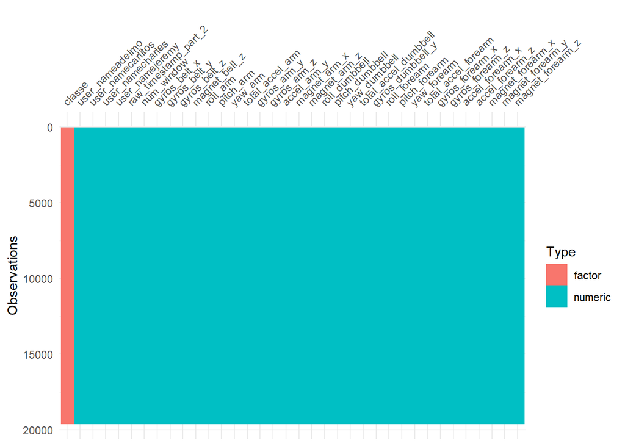

```r
visdat::vis_dat(df)
```

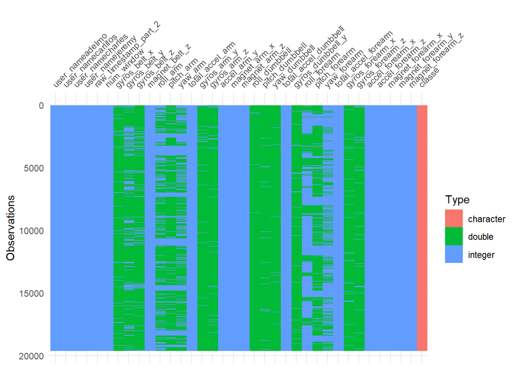

```r
visdat::vis_guess(df)
```

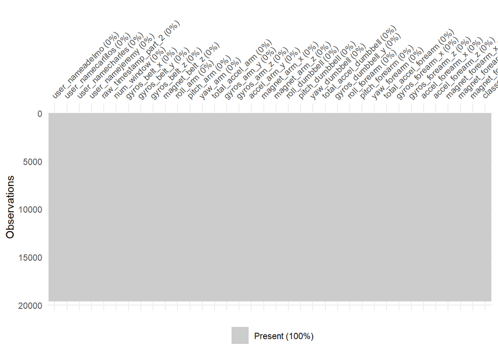

```r
visdat::vis_miss(df)
```

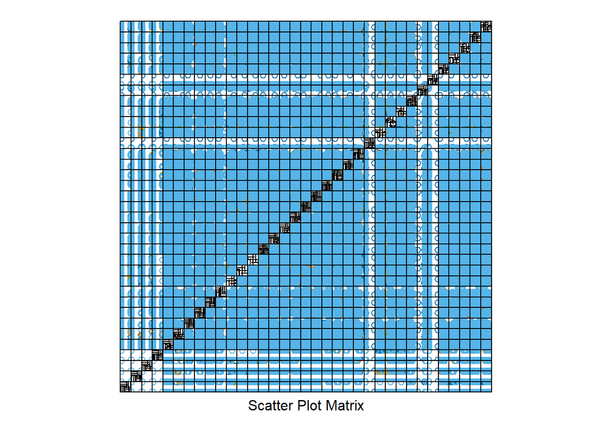

```r
featurePlot(x = df[, -which(names(df) == "classe")], y =df$classe, plot = 'pairs')
```

```r
#featurePlot(x = df[, setdiff(names(df), "classe")], y =df$classe, plot = 'box')
```

As there are no NAs in the dataset, there is no need for NA imputation.

```r
df |> is.na() |> colSums() |> as_tibble() %>% arrange(value, desc = TRUE)
```

```
## # A tibble: 36 × 1
##    value
##    <dbl>
##  1     0
##  2     0
##  3     0
##  4     0
##  5     0
##  6     0
##  7     0
##  8     0
##  9     0
## 10     0
## # ℹ 26 more rows
```

The dependent variable is multinomial. There is some imbalance, but it is not strong.

```r
table(df$classe) |> prop.table() |> knitr::kable()
```

| Var1 | Freq |
| --- | --- |
| A | 0.2843747 |
| B | 0.1935073 |
| C | 0.1743961 |
| D | 0.1638977 |
| E | 0.1838243 |

### Modelling

Let’s split the dataset into training set and test set.

```r
set.seed(123)
trainIndex <- createDataPartition(df$classe, p = 0.75, list = FALSE)
trainingSet <- df[trainIndex,]
testSet <- df[-trainIndex,]
```

The next step is to define a trainControl function. CV with 5 folds is defined, for the sake of time. I save predictions of each subfold and class probabilities.

```r
ctrl <- trainControl(
  method = "cv",#repeatedcv
  number = 5,
  #repeats = 5,
  savePredictions = "final",
  #multiClassSummary = TRUE,
  classProbs = TRUE,
  verboseIter = FALSE,
  allowParallel = TRUE
)
```

Given the complexity of the models, the estimation is “parallelized”.

```r
library(doParallel)
# Check how many cores you have to work with
detectCores()
```

```
## [1] 12
```

```r
# Set the number of clusters caret has to work with. Creates number of clusters = cores-1
cl <- makePSOCKcluster(detectCores() - 2)

#cl <- makePSOCKcluster(8)
registerDoParallel(cl)
getDoParWorkers()
```

```
## [1] 10
```

Nine different models are tested. A wrapping function is used to pass all the models at once.

```r
# define models to try
models <- c("multinom", "lda", "naive_bayes", "svmRadial", "knn", "rpart", "ranger", "glmnet", "nnet")

# set CV control for knn, k-folds
# control <- trainControl(method = "cv", number = 10, p = .9) # 10 fold, 10%

# fit models

train_models <- lapply(models, function(model){
    print(model)
    set.seed(123)
    train(classe ~ .,
          method = model,
          data = trainingSet,
          trControl = ctrl,
          preProcess = c("center","scale"),
          metric = "Kappa",
          tuneLength = 10)
})
```

```
## [1] "multinom"
## [1] "lda"
## [1] "naive_bayes"
## [1] "svmRadial"
## [1] "knn"
## [1] "rpart"
## [1] "ranger"
## [1] "glmnet"
```

```
## [1] "nnet"
```

```r
names(train_models) <- models


stopCluster(cl)
registerDoSEQ()
```

Now, let’s see the summary results for each method:

```r
resamples(train_models) |> summary()
```

```
##
## Call:
## summary.resamples(object = resamples(train_models))
##
## Models: multinom, lda, naive_bayes, svmRadial, knn, rpart, ranger, glmnet, nnet
## Number of resamples: 5
##
## Accuracy
##                  Min.   1st Qu.    Median      Mean   3rd Qu.      Max. NA's
## multinom    0.5942275 0.5974864 0.6009517 0.6015088 0.6024465 0.6124321    0
## lda         0.5886549 0.5931339 0.5942275 0.5938307 0.5959905 0.5971467    0
## naive_bayes 0.7111791 0.7130730 0.7252038 0.7212941 0.7256968 0.7313179    0
## svmRadial   0.8297655 0.8308424 0.8325976 0.8336060 0.8332201 0.8416044    0
## knn         0.9408767 0.9473148 0.9493886 0.9475466 0.9497453 0.9504076    0
## rpart       0.6083560 0.6222826 0.6523955 0.6442484 0.6641766 0.6740313    0
## ranger      0.9952462 0.9955812 0.9962636 0.9961272 0.9966021 0.9969429    0
## glmnet      0.5486064 0.5616299 0.5616718 0.5596533 0.5625000 0.5638587    0
## nnet        0.8664174 0.8695209 0.8730051 0.8719925 0.8750000 0.8760190    0
##
## Kappa
##                  Min.   1st Qu.    Median      Mean   3rd Qu.      Max. NA's
## multinom    0.4852997 0.4893654 0.4931222 0.4944000 0.4962871 0.5079256    0
## lda         0.4794062 0.4847898 0.4868927 0.4861762 0.4895549 0.4902375    0
## naive_bayes 0.6346709 0.6399725 0.6516901 0.6477652 0.6524509 0.6600414    0
## svmRadial   0.7830249 0.7844947 0.7867240 0.7880824 0.7876580 0.7985104    0
## knn         0.9252704 0.9333455 0.9359710 0.9336552 0.9364361 0.9372530    0
## rpart       0.5024526 0.5228816 0.5548358 0.5466357 0.5698626 0.5831457    0
## ranger      0.9939878 0.9944104 0.9952737 0.9951015 0.9957021 0.9961333    0
## glmnet      0.4242584 0.4417969 0.4419617 0.4391091 0.4428442 0.4446842    0
## nnet        0.8309991 0.8349822 0.8395231 0.8381342 0.8419477 0.8432191    0
```

Nice, our best models are random forests (ranger), knn and neural nets. But, these results pertain to the training set.

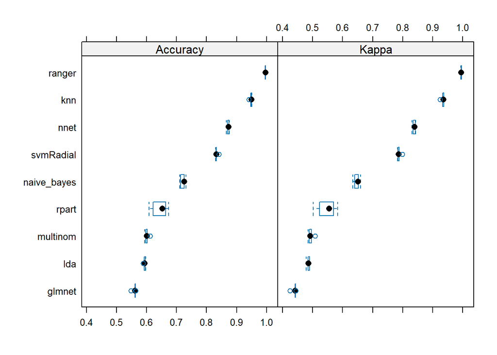

```r
bwplot(resamples(train_models))
```

The random forest model has an outstanding performance. Let’s see its behavior during the tunning process:

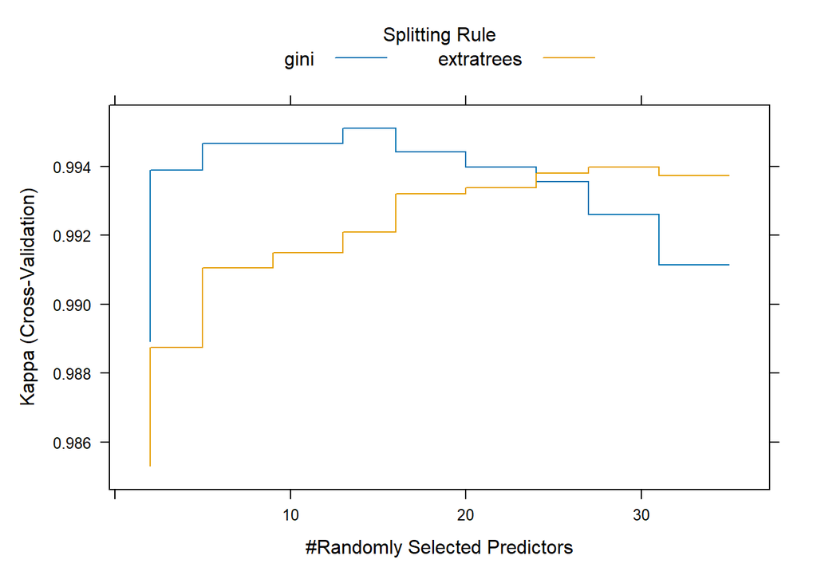

```r
plot(train_models$ranger, print.thres = 0.5, type="S")
```

Below, one may find the results of the tunning process of the ranger model:

```r
train_models$ranger$results
```

```
##    mtry min.node.size  splitrule  Accuracy     Kappa   AccuracySD      KappaSD
## 1     2             1       gini 0.9912349 0.9889121 0.0014713192 0.0018619494
## 2     2             1 extratrees 0.9883814 0.9853022 0.0018529431 0.0023444055
## 3     5             1       gini 0.9951761 0.9938983 0.0012793425 0.0016177325
## 4     5             1 extratrees 0.9910992 0.9887410 0.0024901563 0.0031493596
## 5     9             1       gini 0.9957875 0.9946719 0.0009175563 0.0011603605
## 6     9             1 extratrees 0.9929339 0.9910621 0.0011860542 0.0014995927
## 7    13             1       gini 0.9957874 0.9946717 0.0010082295 0.0012750976
## 8    13             1 extratrees 0.9932735 0.9914916 0.0011372907 0.0014383622
## 9    16             1       gini 0.9961272 0.9951015 0.0007042430 0.0008906403
## 10   16             1 extratrees 0.9937492 0.9920932 0.0009784504 0.0012371935
## 11   20             1       gini 0.9955838 0.9944142 0.0008649619 0.0010937553
## 12   20             1 extratrees 0.9946324 0.9932105 0.0010850181 0.0013720383
## 13   24             1       gini 0.9952438 0.9939841 0.0009307749 0.0011773089
## 14   24             1 extratrees 0.9947684 0.9933826 0.0007807620 0.0009870496
## 15   27             1       gini 0.9949041 0.9935543 0.0014218839 0.0017987446
## 16   27             1 extratrees 0.9951079 0.9938120 0.0010639936 0.0013457479
## 17   31             1       gini 0.9941566 0.9926092 0.0011878478 0.0015026340
## 18   31             1 extratrees 0.9952439 0.9939841 0.0009608578 0.0012152244
## 19   35             1       gini 0.9930016 0.9911483 0.0013729492 0.0017368401
## 20   35             1 extratrees 0.9950400 0.9937262 0.0011670257 0.0014759902
```

So, our best tunning parameters are as follows:

```r
train_models$ranger$bestTune
```

```
##   mtry splitrule min.node.size
## 9   16      gini             1
```

Also remarkable is that results are consistent across folds.

```r
train_models$ranger$resample
```

```
##    Accuracy     Kappa Resample
## 1 0.9952462 0.9939878    Fold2
## 2 0.9962636 0.9952737    Fold3
## 3 0.9955812 0.9944104    Fold5
## 4 0.9969429 0.9961333    Fold4
## 5 0.9966021 0.9957021    Fold1
```

But, how does each model behave in the testing set?

Now, let’s see how the different models behaved:

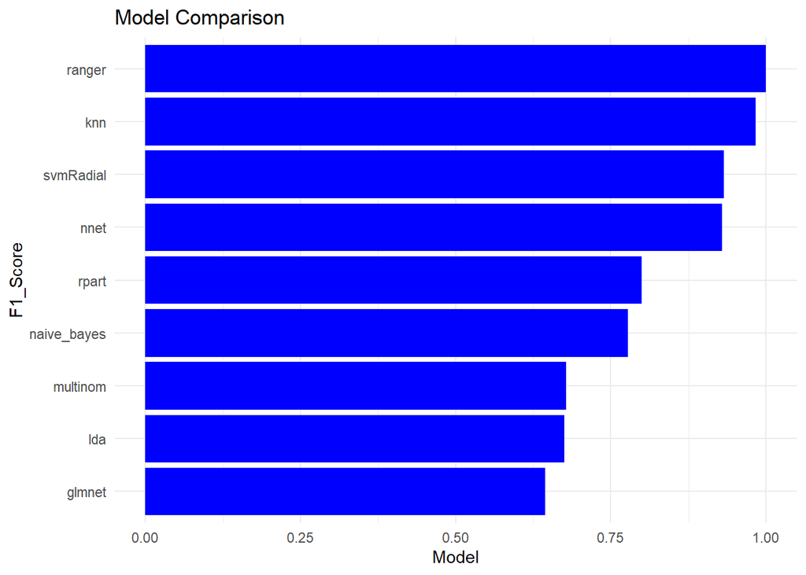

```r
sapply(train_models,
       function(x){
         pred <- predict(x, testSet)
         MLmetrics::F1_Score(y_true = testSet$classe, y_pred = pred)

       }) |> reshape2::melt() %>%
#rowid_to_column() %>%
  rownames_to_column(var = "model")|>
  ggplot(aes(x=reorder(model, value), y=value))+
  geom_bar(stat="identity", fill = "blue")+
  ggtitle("Model Comparison")+
  labs(x="F1_Score", y="Model")+
  coord_flip() +
  theme_minimal()
```

Ok, these results also point to the prevalence of the random forest model as the one displaying larger out of sample accuracy.

What about variable importance? For that, one has to retrain our model and define “importance = impurity”

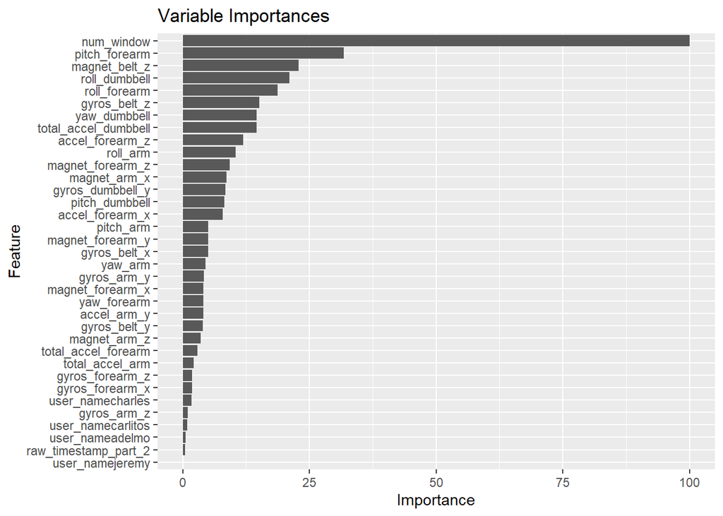

```r
train(classe ~ .,
          method = "ranger",
          data = trainingSet,
          trControl = ctrl,
          preProcess = c("center","scale"),
#          metric = "Kappa",
          importance='impurity',
          tuneGrid = train_models$ranger$bestTune) %>%
          varImp(.) %>%
          ggplot() +
          ggtitle("Variable Importances")
```

Now, let’s see some additional out of sample prediction stats:

```r
# Calculate performance on the Test. Pass two vector to calculate performance metrics
ranger_fit <- train_models$ranger
pred <- predict(ranger_fit, testSet) |> as_data_frame()
confusionMatrix(factor(testSet$classe), factor(pred$value))
```

```
## Confusion Matrix and Statistics
##
##           Reference
## Prediction    A    B    C    D    E
##          A 1395    0    0    0    0
##          B    0  949    0    0    0
##          C    0    2  853    0    0
##          D    0    1    3  800    0
##          E    0    0    0    0  901
##
## Overall Statistics
##
##                Accuracy : 0.9988
##                  95% CI : (0.9973, 0.9996)
##     No Information Rate : 0.2845
##     P-Value [Acc > NIR] : < 2.2e-16
##
##                   Kappa : 0.9985
##
##  Mcnemar's Test P-Value : NA
##
## Statistics by Class:
##
##                      Class: A Class: B Class: C Class: D Class: E
## Sensitivity            1.0000   0.9968   0.9965   1.0000   1.0000
## Specificity            1.0000   1.0000   0.9995   0.9990   1.0000
## Pos Pred Value         1.0000   1.0000   0.9977   0.9950   1.0000
## Neg Pred Value         1.0000   0.9992   0.9993   1.0000   1.0000
## Prevalence             0.2845   0.1941   0.1746   0.1631   0.1837
## Detection Rate         0.2845   0.1935   0.1739   0.1631   0.1837
## Detection Prevalence   0.2845   0.1935   0.1743   0.1639   0.1837
## Balanced Accuracy      1.0000   0.9984   0.9980   0.9995   1.0000
```

```r
postResample(factor(testSet$classe), factor(pred$value))
```

```
##  Accuracy     Kappa
## 0.9987765 0.9984524
```

```r
## or predicting using the probabilities (nice because you can get ROC)
probs <- extractProb(list(model=ranger_fit), testX = testSet, testY = testSet$classe)

#predict(ranger_fit, testSet, type = "prob")
```

```r
## Make sure the levels are appropriate for multiClassSummary(), ie case group is first level
levs <- LETTERS[1:5]
probs$obs <- factor(probs$obs, levels = levs)
probs$pred <- factor(probs$pred, levels = levs)
```

```r
## Calculating Accuracy
mean(probs$obs==probs$pred)
```

```
## [1] 0.9996942
```

```r
## pred column shows model predicted label if cutoff for calling label = 0.5
table(probs$obs, probs$pred)
```

```
##
##        A    B    C    D    E
##   A 5580    0    0    0    0
##   B    0 3797    0    0    0
##   C    0    2 3420    0    0
##   D    0    1    3 3212    0
##   E    0    0    0    0 3607
```

```r
multiClassSummary(probs, lev = levels(probs$obs))
```

```
##                logLoss                    AUC                  prAUC
##             0.03410196             0.99999940             0.86723207
##               Accuracy                  Kappa                Mean_F1
##             0.99969422             0.99961324             0.99965047
##       Mean_Sensitivity       Mean_Specificity    Mean_Pos_Pred_Value
##             0.99963435             0.99992505             0.99966682
##    Mean_Neg_Pred_Value         Mean_Precision            Mean_Recall
##             0.99992656             0.99966682             0.99963435
##    Mean_Detection_Rate Mean_Balanced_Accuracy
##             0.19993884             0.99977970
```

```r
library(pROC)
rangerROC <- roc(testSet$classe |> factor(), probs$A[probs$dataType== "Test"])
rangerROC
```

```
##
## Call:
## roc.default(response = factor(testSet$classe), predictor = probs$A[probs$dataType ==     "Test"])
##
## Data: probs$A[probs$dataType == "Test"] in 1395 controls (factor(testSet$classe) A) > 949 cases (factor(testSet$classe) B).
## Area under the curve: 1
```

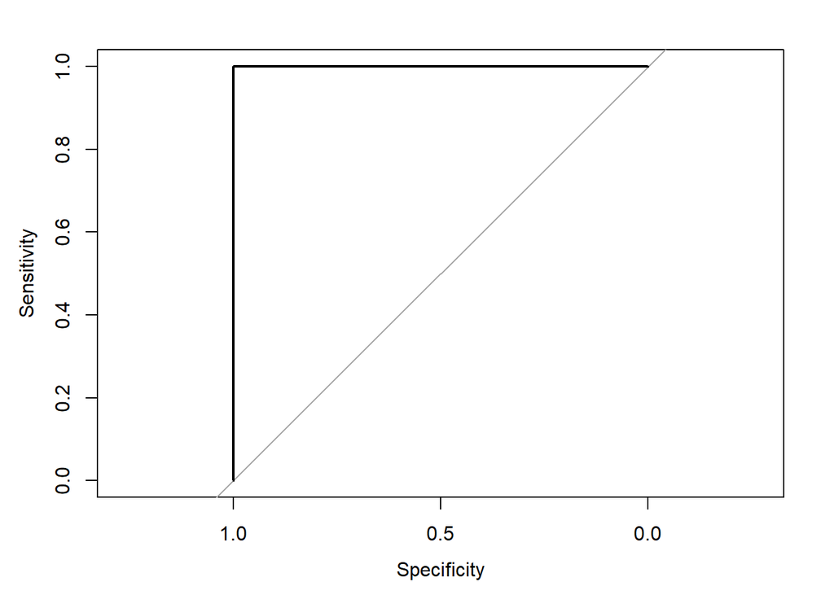

```r
plot(rangerROC, metric = "ROC")
```

Let’s compare our two best models:

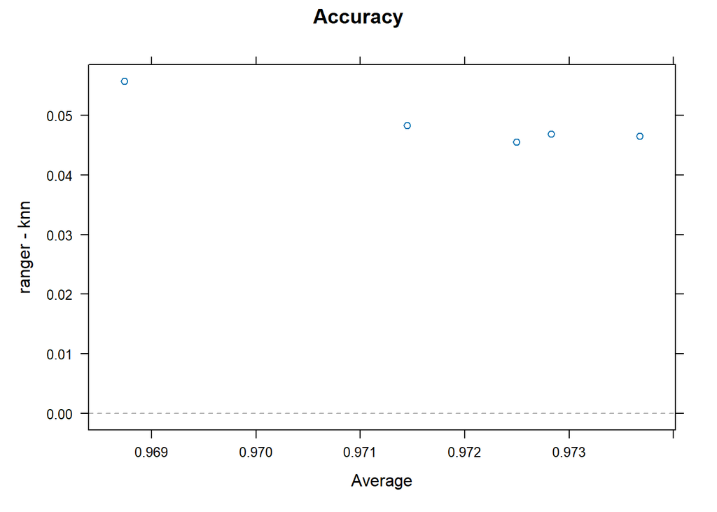

```r
train_models[c("ranger", "knn")] |> resamples() |>
  xyplot(., what = "BlandAltman")
```

```r
train_models[c("ranger", "knn")] |>
  resamples() |>
  diff() |>
  summary()
```

```
##
## Call:
## summary.diff.resamples(object =
##  diff(resamples(train_models[c("ranger", "knn")])))
##
## p-value adjustment: bonferroni
## Upper diagonal: estimates of the difference
## Lower diagonal: p-value for H0: difference = 0
##
## Accuracy
##        ranger    knn
## ranger           0.04858
## knn    1.223e-05
##
## Kappa
##        ranger    knn
## ranger           0.06145
## knn    1.199e-05
```

Random forest seems to clearly outperform KNN.

### Final Predictions

```r
validation_set2 <- validation_set %>%
  select(any_of(nonMissingVars))

validation_set2 <- validation_set2 %>%
  select(!names(validation_set2)[nsv_obj$nzv])


validation_set2 <- dummyVars( ~ ., validation_set2) %>%
  predict(validation_set2) %>%
  as.data.frame()



validation_set2 %<>%
  select(-any_of(correl_cols))

predict(ranger_fit, validation_set2) |> as_data_frame()
```

```
## # A tibble: 20 × 1
##    value
##    <fct>
##  1 B
##  2 A
##  3 B
##  4 A
##  5 A
##  6 E
##  7 D
##  8 B
##  9 A
## 10 A
## 11 B
## 12 C
## 13 B
## 14 A
## 15 E
## 16 E
## 17 A
## 18 B
## 19 B
## 20 B
```